# ds_nov

## mpagodeservicios

| Feature | Result |
| --- | --- |
| Variable type | numeric |
| Number of missing obs. | 0 (0 %) |
| Number of unique values | 1783 |
| Median | 0 |
| 1st and 3rd quartiles | 0; 0 |
| Min. and max. | 0; 3732278.12 |

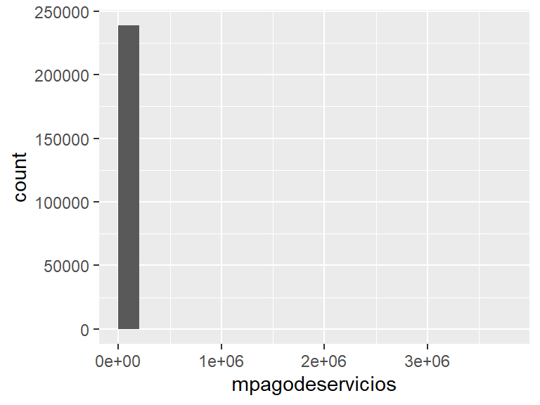

- Note that the following possible outlier values were detected: "11.7", "14", "15.6", "20.61", "33.97", "35.1", "53.02", "58.5", "65.83", "70.2" (1772 additional values omitted).

## cpagomiscuentas

| Feature | Result |
| --- | --- |
| Variable type | integer |
| Number of missing obs. | 0 (0 %) |
| Number of unique values | 79 |
| Median | 1 |
| 1st and 3rd quartiles | 0; 3 |
| Min. and max. | 0; 363 |

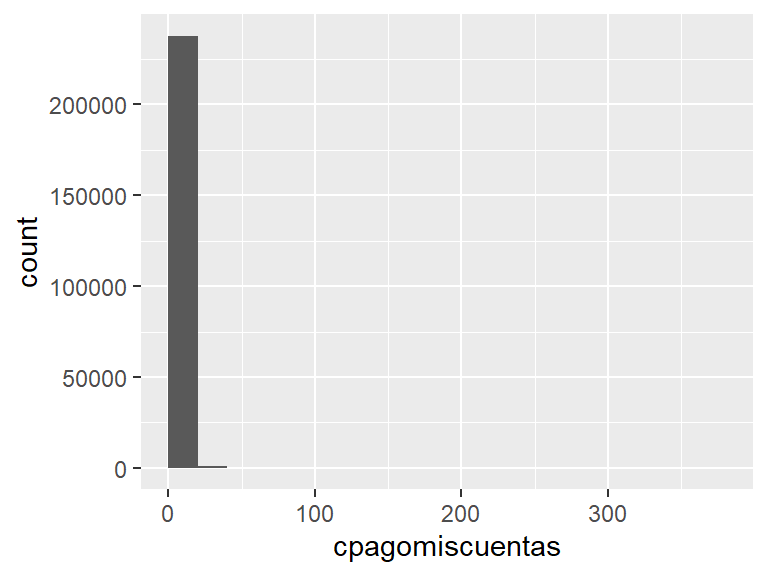

- Note that the following possible outlier values were detected: "24", "25", "26", "27", "28", "29", "30", "31", "32", "33" (45 additional values omitted).

## mpagomiscuentas

| Feature | Result |
| --- | --- |
| Variable type | numeric |
| Number of missing obs. | 0 (0 %) |
| Number of unique values | 104501 |
| Median | 0.34 |
| 1st and 3rd quartiles | 0; 9836.52 |
| Min. and max. | 0; 27569330.46 |

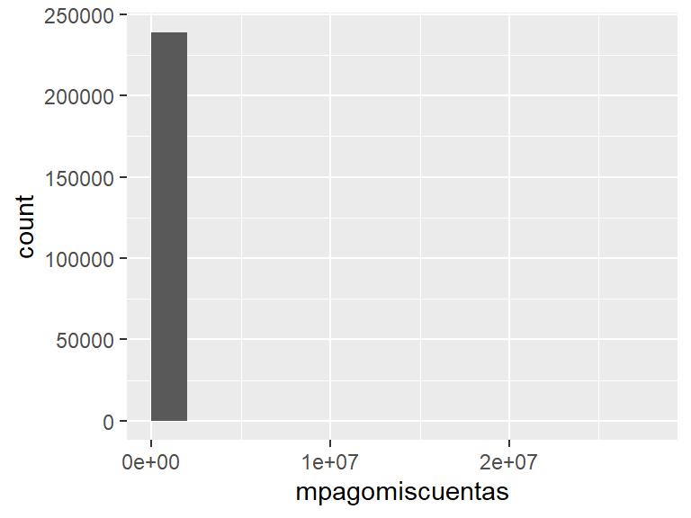

- Note that the following possible outlier values were detected: "306544.96", "306843.05", "306974.43", "307593", "308138.29", "308186.45", "308237.95", "308517.14", "308576.11", "308663.73" (893 additional values omitted).

## ccajeros_propios_descuentos

| Feature | Result |
| --- | --- |
| Variable type | integer |
| Number of missing obs. | 0 (0 %) |
| Number of unique values | 23 |
| Median | 0 |
| 1st and 3rd quartiles | 0; 0 |
| Min. and max. | 0; 23 |

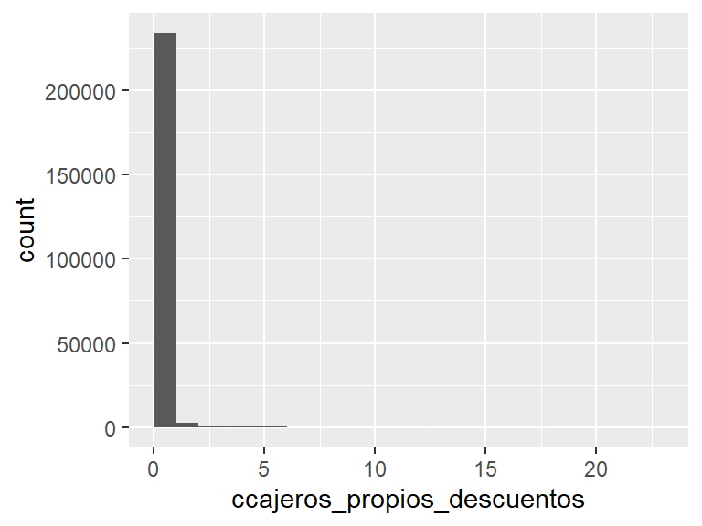

- Note that the following possible outlier values were detected: "1", "2", "3", "4", "5", "6", "7", "8", "9", "10" (12 additional values omitted).

## mcajeros_propios_descuentos

| Feature | Result |
| --- | --- |
| Variable type | numeric |
| Number of missing obs. | 0 (0 %) |
| Number of unique values | 6502 |
| Median | 0 |
| 1st and 3rd quartiles | 0; 0 |
| Min. and max. | 0; 20191.27 |

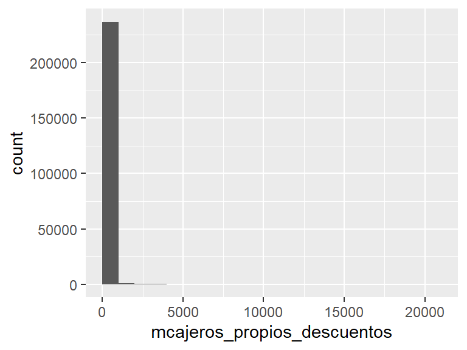

- Note that the following possible outlier values were detected: "0.01", "0.02", "0.17", "0.23", "0.35", "0.94", "1.75", "2.34", "3.51", "4.68" (6491 additional values omitted).

## ctarjeta_visa_descuentos

| Feature | Result |
| --- | --- |
| Variable type | integer |
| Number of missing obs. | 0 (0 %) |
| Number of unique values | 18 |
| Median | 0 |
| 1st and 3rd quartiles | 0; 0 |
| Min. and max. | 0; 18 |

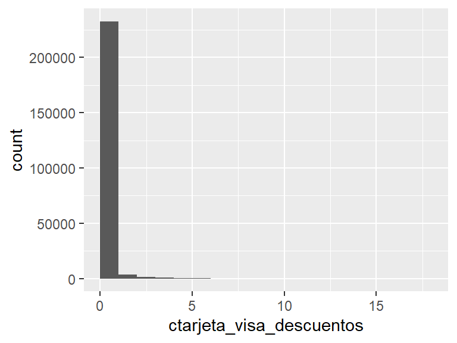

- Note that the following possible outlier values were detected: "1", "2", "3", "4", "5", "6", "7", "8", "9", "10" (7 additional values omitted).

## mtarjeta_visa_descuentos

| Feature | Result |
| --- | --- |
| Variable type | numeric |
| Number of missing obs. | 4397 (1.84 %) |
| Number of unique values | 10406 |
| Median | 0 |
| 1st and 3rd quartiles | 0; 0 |
| Min. and max. | 0; 41776.37 |

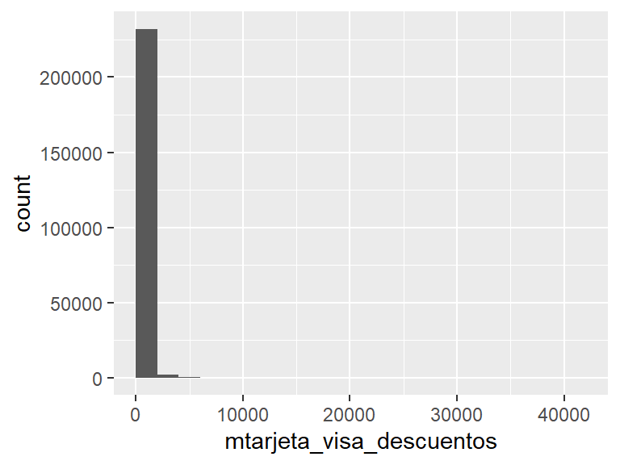

- Note that the following possible outlier values were detected: "0.42", "0.7", "1.4", "1.46", "2.34", "5.85", "6.27", "6.87", "7.6", "8.14" (10395 additional values omitted).

## ctarjeta_master_descuentos

| Feature | Result |
| --- | --- |
| Variable type | integer |
| Number of missing obs. | 0 (0 %) |
| Number of unique values | 15 |
| Median | 0 |
| 1st and 3rd quartiles | 0; 0 |
| Min. and max. | 0; 16 |

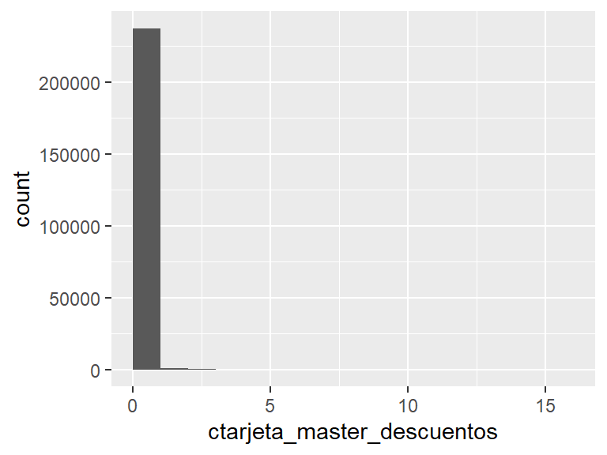

- Note that the following possible outlier values were detected: "1", "2", "3", "4", "5", "6", "7", "8", "9", "10" (4 additional values omitted).

## mtarjeta_master_descuentos

| Feature | Result |
| --- | --- |
| Variable type | numeric |
| Number of missing obs. | 2231 (0.93 %) |
| Number of unique values | 2764 |
| Median | 0 |
| 1st and 3rd quartiles | 0; 0 |
| Min. and max. | 0; 53373.06 |

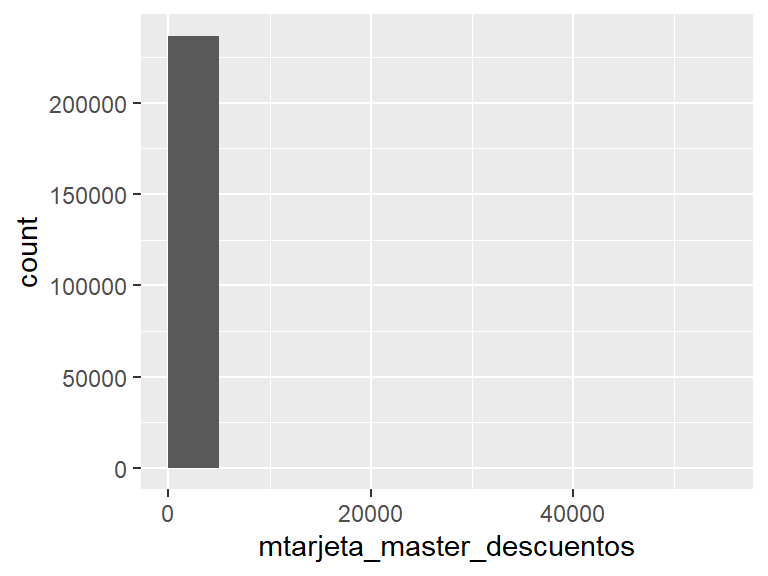

- Note that the following possible outlier values were detected: "0.7", "9.36", "10.5", "11.58", "11.7", "12.28", "12.91", "14.15", "15.94", "18.45" (2753 additional values omitted).

## ccomisiones_mantenimiento

| Feature | Result |
| --- | --- |
| Variable type | integer |
| Number of missing obs. | 0 (0 %) |
| Number of unique values | 20 |
| Median | 0 |
| 1st and 3rd quartiles | 0; 1 |
| Min. and max. | 0; 44 |

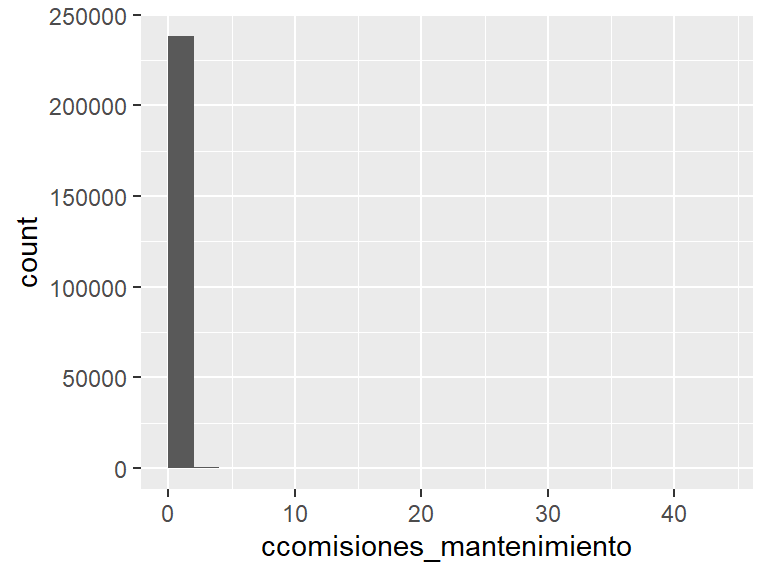

- Note that the following possible outlier values were detected: "44".

## mcomisiones_mantenimiento

| Feature | Result |
| --- | --- |
| Variable type | numeric |
| Number of missing obs. | 0 (0 %) |
| Number of unique values | 610 |
| Median | 0 |
| 1st and 3rd quartiles | 0; 961.62 |
| Min. and max. | -15716.65; 12515.34 |

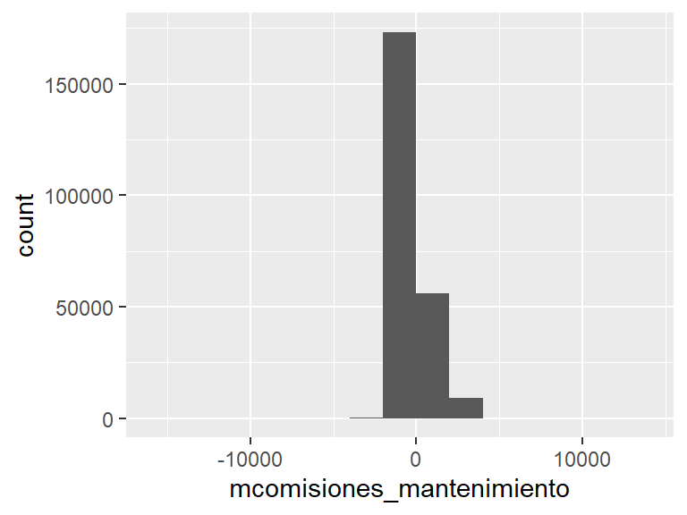

- Note that the following possible outlier values were detected: "-15716.65", "-13097.21", "-11539.47", "-10477.77", "-9616.23", "-9379.32", "-8168.75", "-7858.32", "-7692.98", "-7034.49" (89 additional values omitted).

## ccomisiones_otras

| Feature | Result |
| --- | --- |
| Variable type | integer |
| Number of missing obs. | 0 (0 %) |
| Number of unique values | 183 |
| Median | 8 |
| 1st and 3rd quartiles | 6; 12 |
| Min. and max. | 0; 276 |

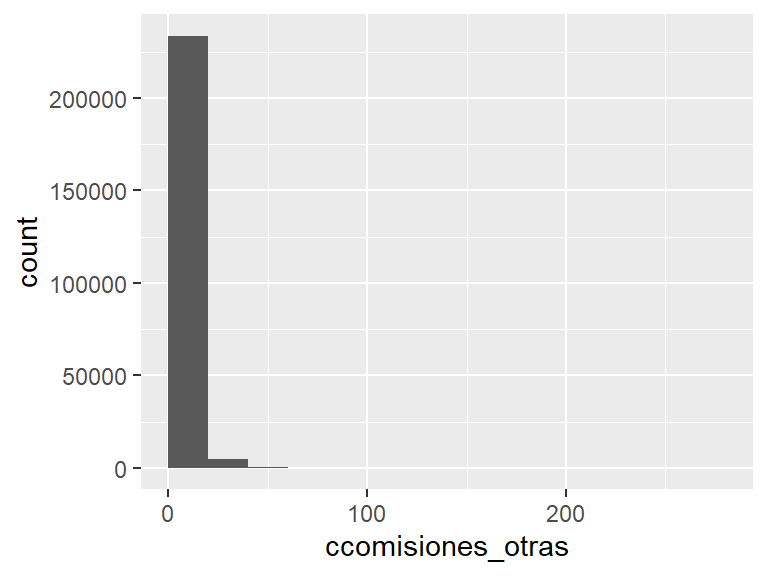

- Note that the following possible outlier values were detected: "22", "23", "24", "25", "26", "27", "28", "29", "30", "31" (151 additional values omitted).

## mcomisiones_otras

| Feature | Result |
| --- | --- |
| Variable type | numeric |
| Number of missing obs. | 0 (0 %) |
| Number of unique values | 152834 |
| Median | 778.36 |
| 1st and 3rd quartiles | 244.3; 1689.31 |
| Min. and max. | -281818.04; 398575.75 |

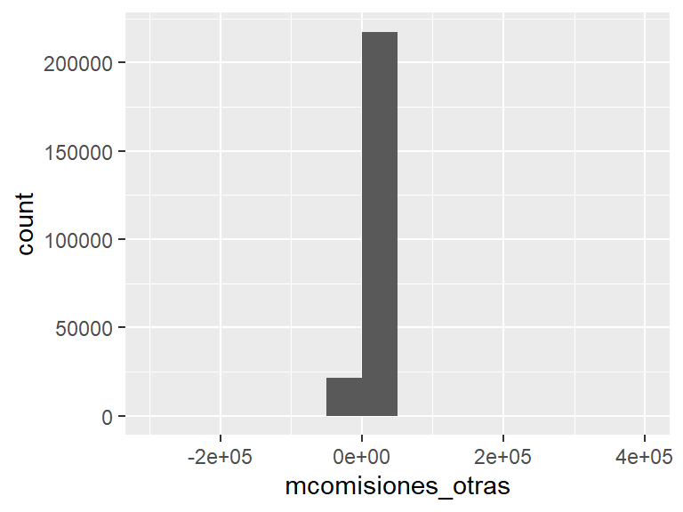

- Note that the following possible outlier values were detected: "-281818.04", "-137463.11", "-103016.79", "-49154.54", "-29682.38", "-25487.35", "-24659.36", "-22126.38", "-21734.14", "-20054.26" (6800 additional values omitted).

## cforex

| Feature | Result |
| --- | --- |
| Variable type | integer |
| Number of missing obs. | 0 (0 %) |
| Number of unique values | 15 |
| Median | 0 |
| 1st and 3rd quartiles | 0; 0 |
| Min. and max. | 0; 17 |

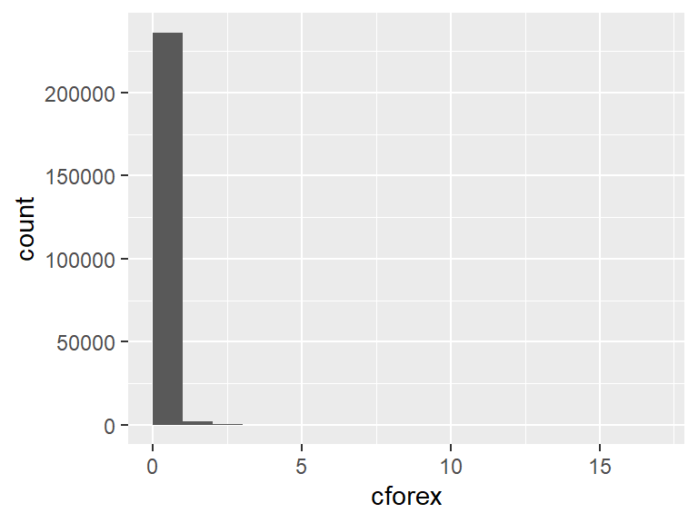

- Note that the following possible outlier values were detected: "1", "2", "3", "4", "5", "6", "7", "8", "9", "10" (4 additional values omitted).

## cforex_buy

| Feature | Result |
| --- | --- |
| Variable type | integer |
| Number of missing obs. | 0 (0 %) |
| Number of unique values | 10 |
| Median | 0 |
| 1st and 3rd quartiles | 0; 0 |
| Min. and max. | 0; 12 |

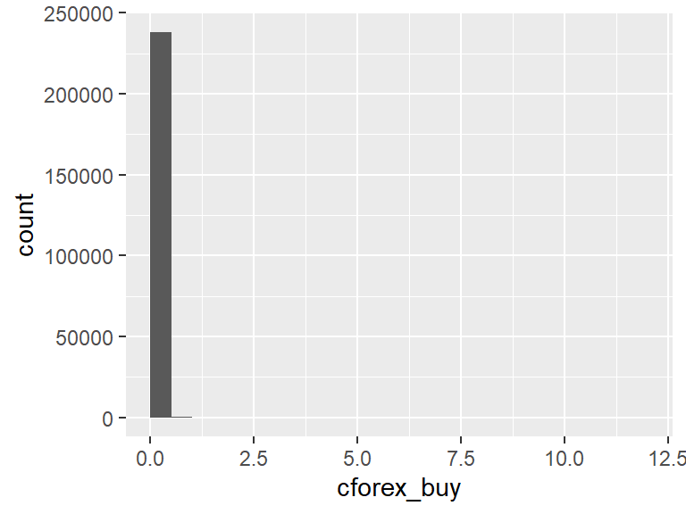

- Note that the following possible outlier values were detected: "1", "2", "3", "4", "5", "6", "7", "8", "12".

## mforex_buy

| Feature | Result |
| --- | --- |
| Variable type | numeric |
| Number of missing obs. | 0 (0 %) |
| Number of unique values | 369 |
| Median | 0 |
| 1st and 3rd quartiles | 0; 0 |
| Min. and max. | 0; 16672.5 |

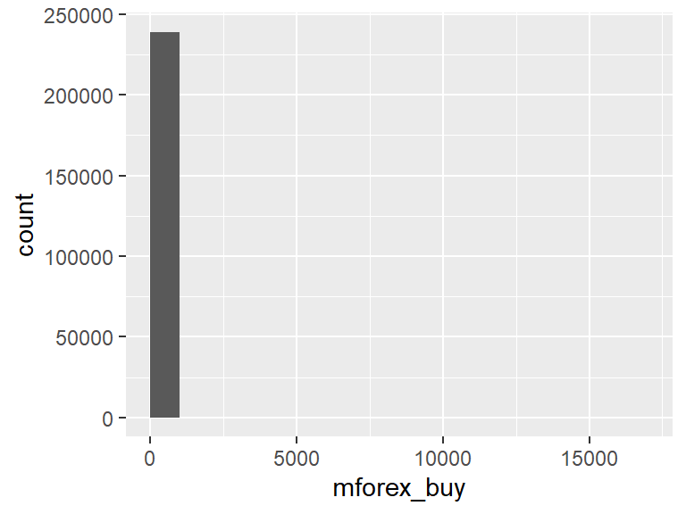

- Note that the following possible outlier values were detected: "1.17", "1.25", "1.35", "1.38", "1.4", "1.45", "1.63", "1.66", "1.74", "1.75" (358 additional values omitted).

## cforex_sell

| Feature | Result |
| --- | --- |
| Variable type | integer |
| Number of missing obs. | 0 (0 %) |
| Number of unique values | 14 |
| Median | 0 |
| 1st and 3rd quartiles | 0; 0 |
| Min. and max. | 0; 17 |

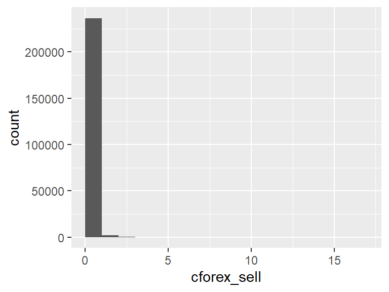

- Note that the following possible outlier values were detected: "1", "2", "3", "4", "5", "6", "7", "8", "9", "10" (3 additional values omitted).

## mforex_sell

| Feature | Result |
| --- | --- |
| Variable type | numeric |
| Number of missing obs. | 0 (0 %) |
| Number of unique values | 647 |
| Median | 0 |
| 1st and 3rd quartiles | 0; 0 |
| Min. and max. | 0; 2998.71 |

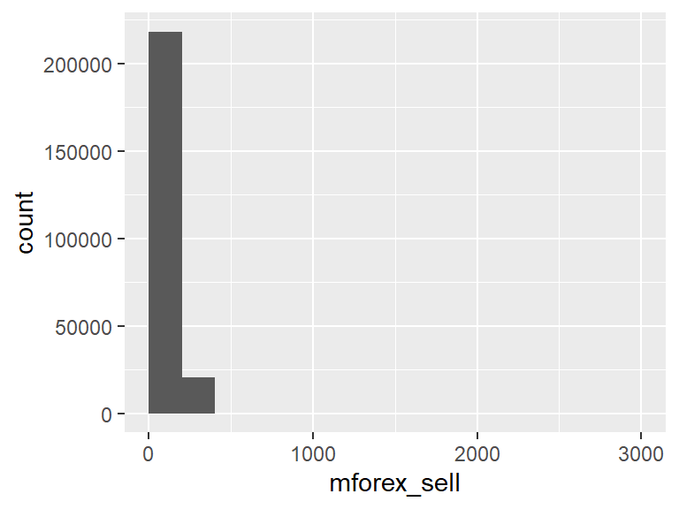

- Note that the following possible outlier values were detected: "1.17", "1.31", "1.48", "2.34", "2.45", "2.71", "3.18", "3.27", "3.51", "4.66" (636 additional values omitted).

## ctransferencias_recibidas

| Feature | Result |
| --- | --- |
| Variable type | integer |
| Number of missing obs. | 0 (0 %) |
| Number of unique values | 248 |
| Median | 2 |
| 1st and 3rd quartiles | 0; 3 |
| Min. and max. | 0; 6606 |

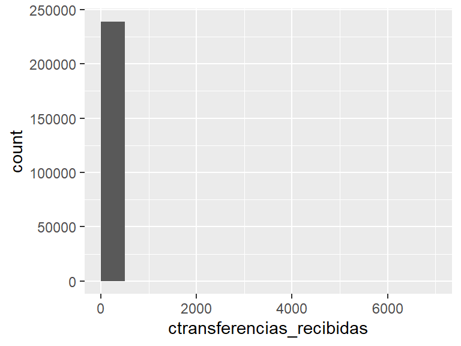

- Note that the following possible outlier values were detected: "12", "13", "14", "15", "16", "17", "18", "19", "20", "21" (226 additional values omitted).

## mtransferencias_recibidas

| Feature | Result |
| --- | --- |
| Variable type | numeric |
| Number of missing obs. | 0 (0 %) |
| Number of unique values | 103891 |
| Median | 29250 |
| 1st and 3rd quartiles | 0; 92724.27 |
| Min. and max. | 0; 495807150.24 |

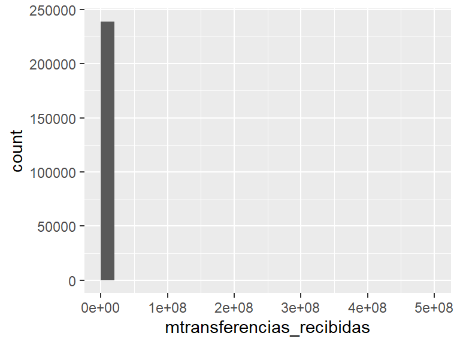

- Note that the following possible outlier values were detected: "669152.61", "669240", "669291.6", "669591", "669754.8", "669883.19", "669956", "670023.53", "670299.65", "670371.64" (4972 additional values omitted).

## ctransferencias_emitidas

| Feature | Result |
| --- | --- |
| Variable type | integer |
| Number of missing obs. | 0 (0 %) |
| Number of unique values | 124 |
| Median | 1 |
| 1st and 3rd quartiles | 0; 4 |
| Min. and max. | 0; 339 |

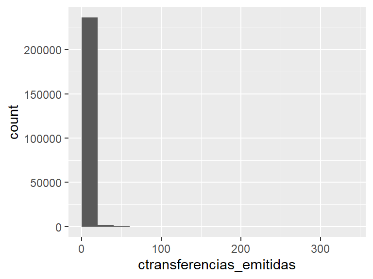

- Note that the following possible outlier values were detected: "41", "42", "43", "44", "45", "46", "47", "48", "49", "50" (73 additional values omitted).

## mtransferencias_emitidas

| Feature | Result |
| --- | --- |
| Variable type | numeric |
| Number of missing obs. | 0 (0 %) |
| Number of unique values | 75259 |
| Median | 6650.06 |
| 1st and 3rd quartiles | 0; 38419.29 |
| Min. and max. | 0; 120651142.31 |

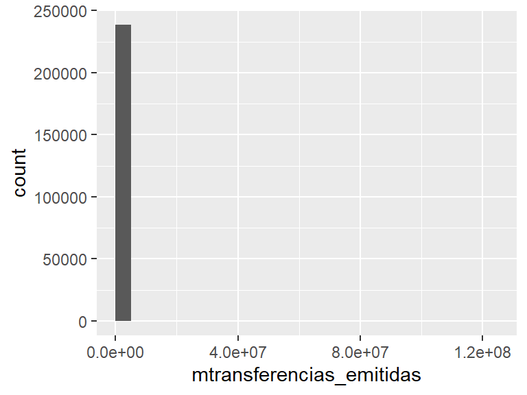

- Note that the following possible outlier values were detected: "500679.56", "500760", "500792.76", "501099.28", "501245.57", "501393.49", "501625.94", "501666.75", "501765.03", "501789.6" (4084 additional values omitted).

## cextraccion_autoservicio

| Feature | Result |
| --- | --- |
| Variable type | integer |
| Number of missing obs. | 0 (0 %) |
| Number of unique values | 79 |
| Median | 0 |
| 1st and 3rd quartiles | 0; 3 |
| Min. and max. | 0; 100 |

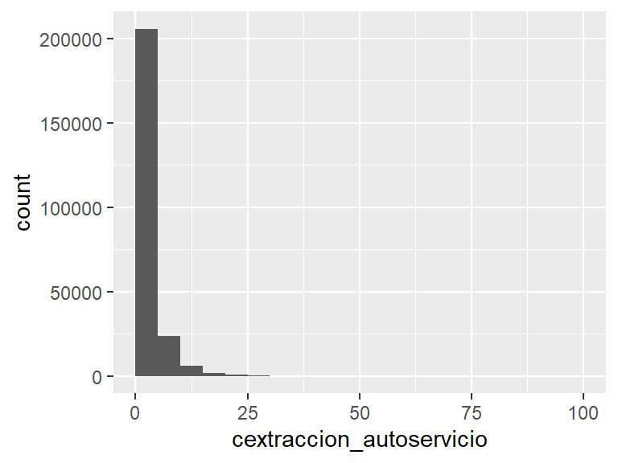

- Note that the following possible outlier values were detected: "95", "100".

## mextraccion_autoservicio

| Feature | Result |
| --- | --- |
| Variable type | numeric |
| Number of missing obs. | 0 (0 %) |
| Number of unique values | 3440 |
| Median | 0 |
| 1st and 3rd quartiles | 0; 23400 |
| Min. and max. | 0; 3247574.96 |

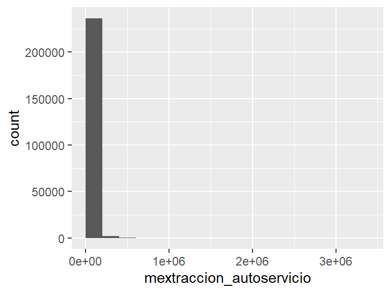

- Note that the following possible outlier values were detected: "748800", "754650", "760500", "764010", "766350", "772200", "778050", "779523.42", "781560", "783315" (52 additional values omitted).

## ccheques_depositados

| Feature | Result |
| --- | --- |
| Variable type | integer |
| Number of missing obs. | 0 (0 %) |
| Number of unique values | 57 |
| Median | 0 |
| 1st and 3rd quartiles | 0; 0 |
| Min. and max. | 0; 182 |

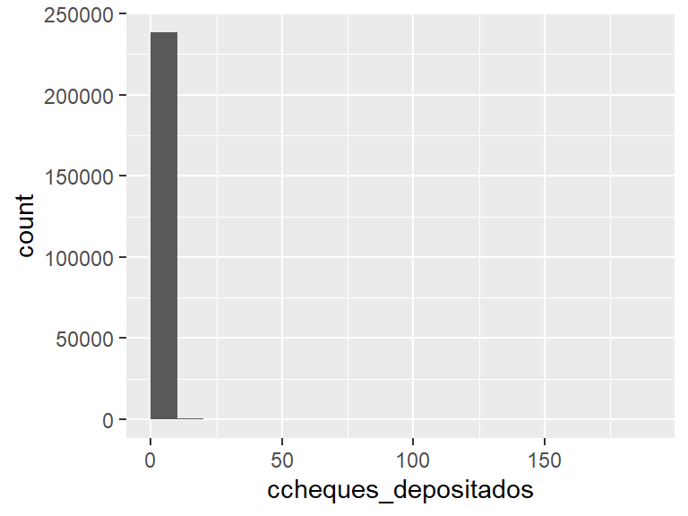

- Note that the following possible outlier values were detected: "1", "2", "3", "4", "5", "6", "7", "8", "9", "10" (46 additional values omitted).

## mcheques_depositados

| Feature | Result |
| --- | --- |
| Variable type | numeric |
| Number of missing obs. | 0 (0 %) |
| Number of unique values | 6330 |
| Median | 0 |
| 1st and 3rd quartiles | 0; 0 |
| Min. and max. | 0; 28875928.31 |

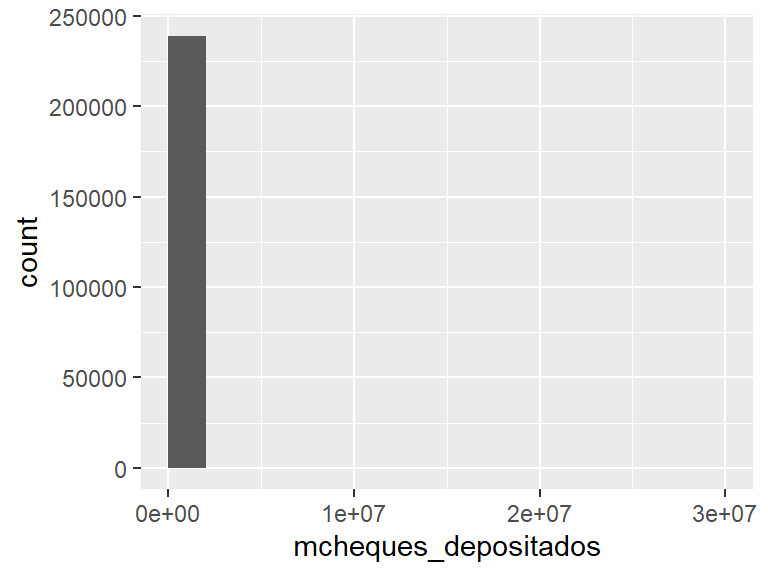

- Note that the following possible outlier values were detected: "117", "378.91", "463.32", "475.72", "558.37", "585", "588.51", "634.01", "655.18", "655.2" (6319 additional values omitted).

## ccheques_emitidos

| Feature | Result |
| --- | --- |
| Variable type | integer |
| Number of missing obs. | 0 (0 %) |
| Number of unique values | 69 |
| Median | 0 |
| 1st and 3rd quartiles | 0; 0 |
| Min. and max. | 0; 126 |

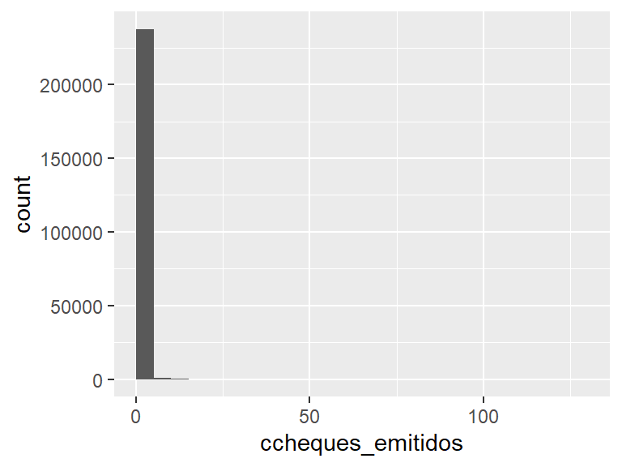

- Note that the following possible outlier values were detected: "1", "2", "3", "4", "5", "6", "7", "8", "9", "10" (58 additional values omitted).

## mcheques_emitidos

| Feature | Result |
| --- | --- |
| Variable type | numeric |
| Number of missing obs. | 0 (0 %) |
| Number of unique values | 4945 |
| Median | 0 |
| 1st and 3rd quartiles | 0; 0 |
| Min. and max. | 0; 32869682.67 |

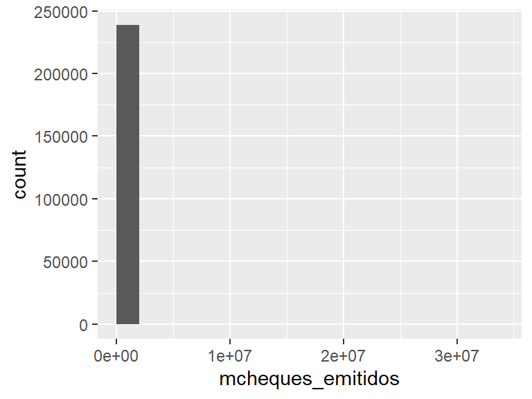

- Note that the following possible outlier values were detected: "164.8", "234", "707.85", "900.9", "1006.2", "1073.34", "1139.58", "1170", "1324.44", "1357.2" (4934 additional values omitted).

## ccheques_depositados_rechazados

| Feature | Result |
| --- | --- |
| Variable type | integer |
| Number of missing obs. | 0 (0 %) |
| Number of unique values | 7 |
| Median | 0 |
| 1st and 3rd quartiles | 0; 0 |
| Min. and max. | 0; 7 |

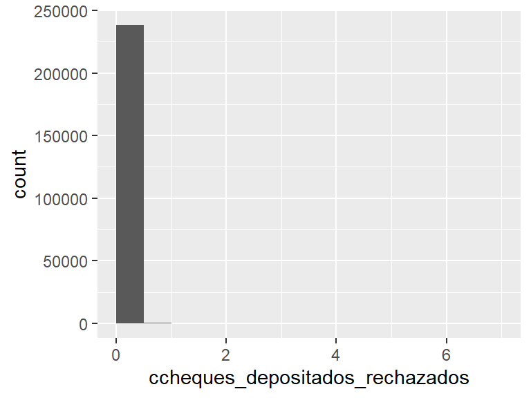

- Note that the following possible outlier values were detected: "1", "2", "3", "4", "5", "7".

## mcheques_depositados_rechazados

| Feature | Result |
| --- | --- |
| Variable type | numeric |
| Number of missing obs. | 0 (0 %) |
| Number of unique values | 320 |
| Median | 0 |
| 1st and 3rd quartiles | 0; 0 |
| Min. and max. | 0; 1860467.33 |

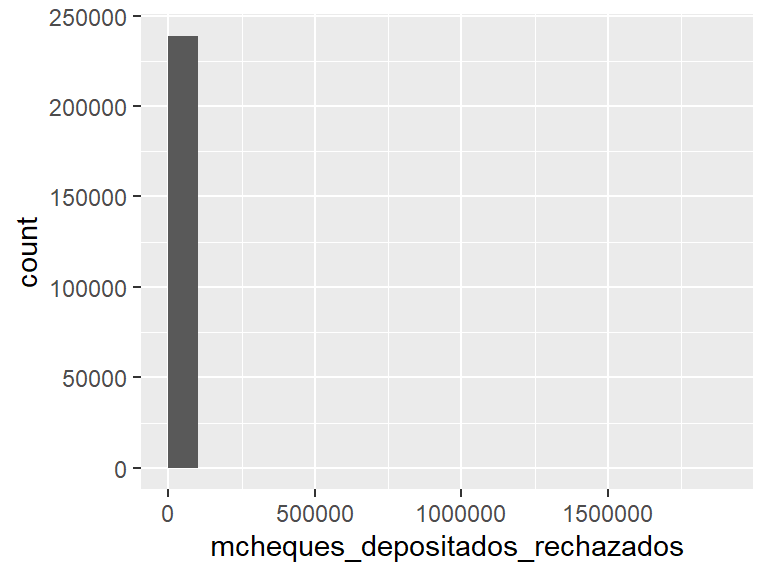

- Note that the following possible outlier values were detected: "1234.35", "3018.6", "3112.2", "3256.11", "3276", "3510", "3659.76", "3978", "4410.9", "4627.35" (309 additional values omitted).

## ccheques_emitidos_rechazados

| Feature | Result |
| --- | --- |
| Variable type | integer |
| Number of missing obs. | 0 (0 %) |
| Number of unique values | 13 |
| Median | 0 |
| 1st and 3rd quartiles | 0; 0 |
| Min. and max. | 0; 33 |

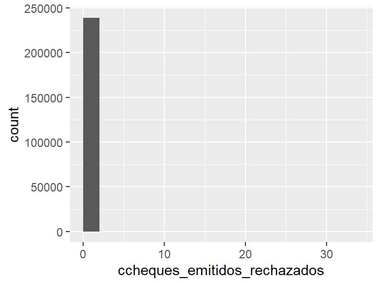

- Note that the following possible outlier values were detected: "1", "2", "3", "4", "5", "6", "7", "8", "9", "11" (2 additional values omitted).

## mcheques_emitidos_rechazados

| Feature | Result |
| --- | --- |
| Variable type | numeric |
| Number of missing obs. | 0 (0 %) |
| Number of unique values | 310 |
| Median | 0 |
| 1st and 3rd quartiles | 0; 0 |
| Min. and max. | 0; 2047197.36 |

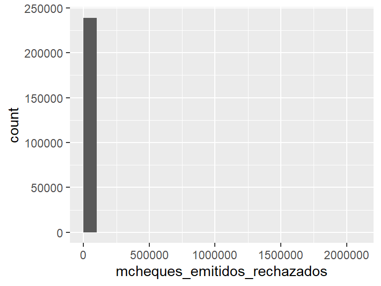

- Note that the following possible outlier values were detected: "1462.5", "2340", "2457", "2812.87", "2971.8", "3276", "3451.5", "3510", "3545.1", "3744" (299 additional values omitted).

## tcallcenter

- Note that this variable is treated as a factor variable below, as it only takes a few unique values.

| Feature | Result |
| --- | --- |
| Variable type | integer |
| Number of missing obs. | 0 (0 %) |
| Number of unique values | 2 |
| Mode | “0” |
| Reference category | 0 |

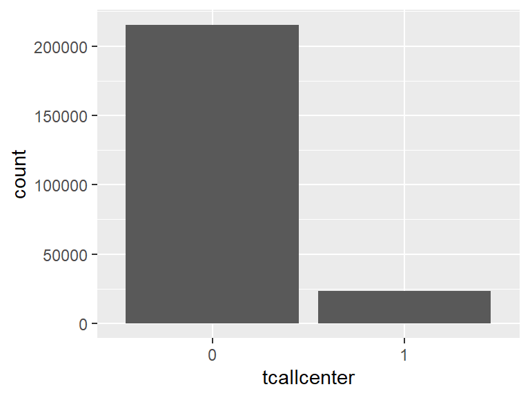

## ccallcenter_transacciones

| Feature | Result |
| --- | --- |
| Variable type | integer |
| Number of missing obs. | 0 (0 %) |
| Number of unique values | 58 |
| Median | 0 |
| 1st and 3rd quartiles | 0; 0 |
| Min. and max. | 0; 84 |

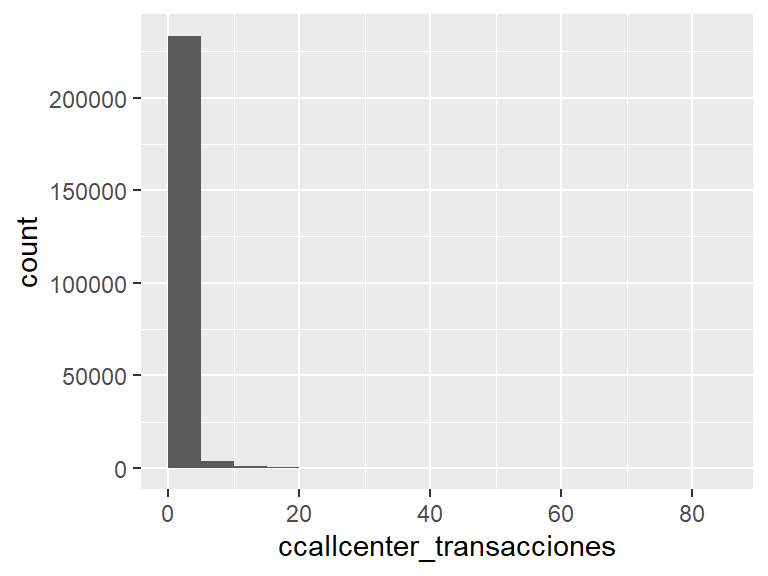

- Note that the following possible outlier values were detected: "1", "2", "3", "4", "5", "6", "7", "8", "9", "10" (47 additional values omitted).

## thomebanking

- Note that this variable is treated as a factor variable below, as it only takes a few unique values.

| Feature | Result |
| --- | --- |
| Variable type | integer |
| Number of missing obs. | 0 (0 %) |
| Number of unique values | 2 |
| Mode | “1” |
| Reference category | 0 |

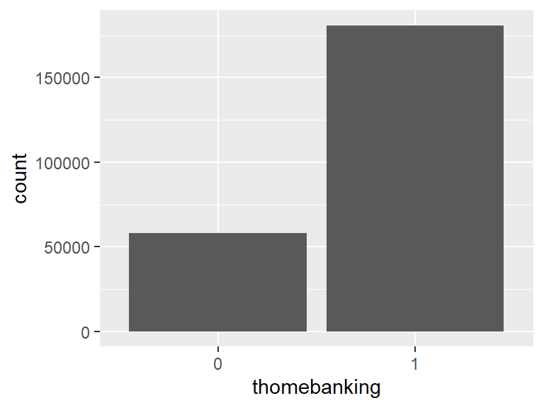

## chomebanking_transacciones

| Feature | Result |
| --- | --- |
| Variable type | integer |
| Number of missing obs. | 0 (0 %) |
| Number of unique values | 818 |
| Median | 26 |
| 1st and 3rd quartiles | 4; 71 |
| Min. and max. | 0; 10038 |

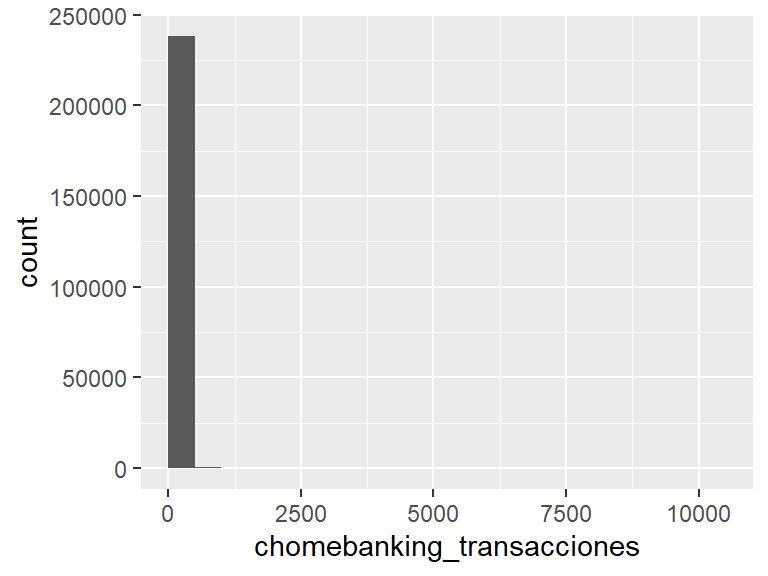

- Note that the following possible outlier values were detected: "439", "440", "441", "442", "443", "444", "445", "446", "447", "448" (369 additional values omitted).

## ccajas_transacciones

- Note that this variable is treated as a factor variable below, as it only takes a few unique values.

| Feature | Result |
| --- | --- |
| Variable type | integer |
| Number of missing obs. | 0 (0 %) |
| Number of unique values | 2 |
| Mode | “0” |
| Reference category | 0 |

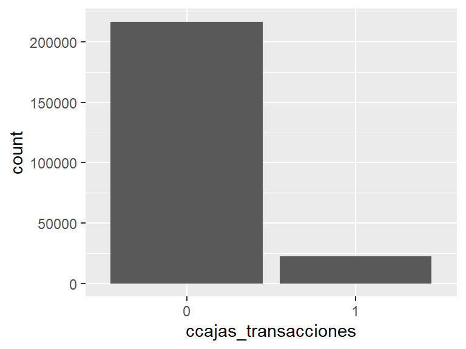

## ccajas_consultas

| Feature | Result |
| --- | --- |
| Variable type | integer |
| Number of missing obs. | 0 (0 %) |
| Number of unique values | 20 |
| Median | 0 |
| 1st and 3rd quartiles | 0; 0 |
| Min. and max. | 0; 25 |

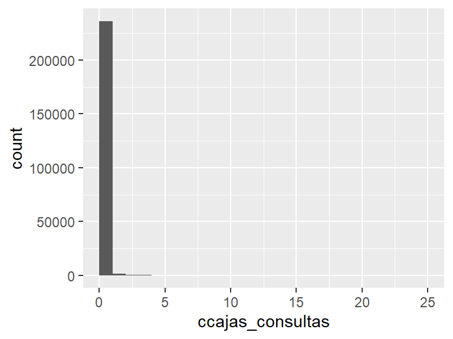

- Note that the following possible outlier values were detected: "1", "2", "3", "4", "5", "6", "7", "8", "9", "10" (9 additional values omitted).

## ccajas_depositos

| Feature | Result |
| --- | --- |
| Variable type | integer |
| Number of missing obs. | 0 (0 %) |
| Number of unique values | 19 |
| Median | 0 |
| 1st and 3rd quartiles | 0; 0 |
| Min. and max. | 0; 33 |

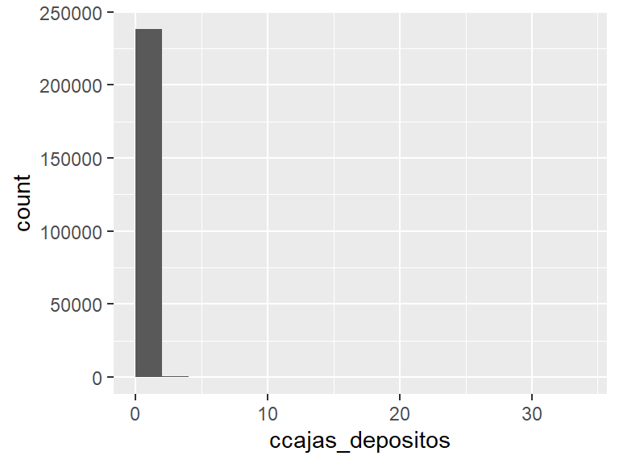

- Note that the following possible outlier values were detected: "1", "2", "3", "4", "5", "6", "7", "8", "9", "10" (8 additional values omitted).

## ccajas_extracciones

| Feature | Result |
| --- | --- |
| Variable type | integer |
| Number of missing obs. | 0 (0 %) |
| Number of unique values | 12 |
| Median | 0 |
| 1st and 3rd quartiles | 0; 0 |
| Min. and max. | 0; 13 |

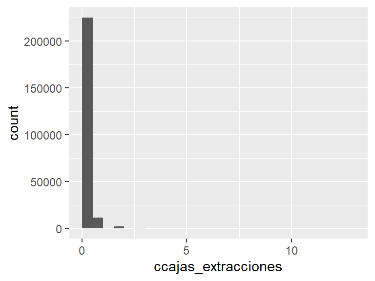

- Note that the following possible outlier values were detected: "1", "2", "3", "4", "5", "6", "7", "8", "9", "10" (1 additional values omitted).

## ccajas_otras

| Feature | Result |
| --- | --- |
| Variable type | integer |
| Number of missing obs. | 0 (0 %) |
| Number of unique values | 20 |
| Median | 0 |
| 1st and 3rd quartiles | 0; 0 |
| Min. and max. | 0; 46 |

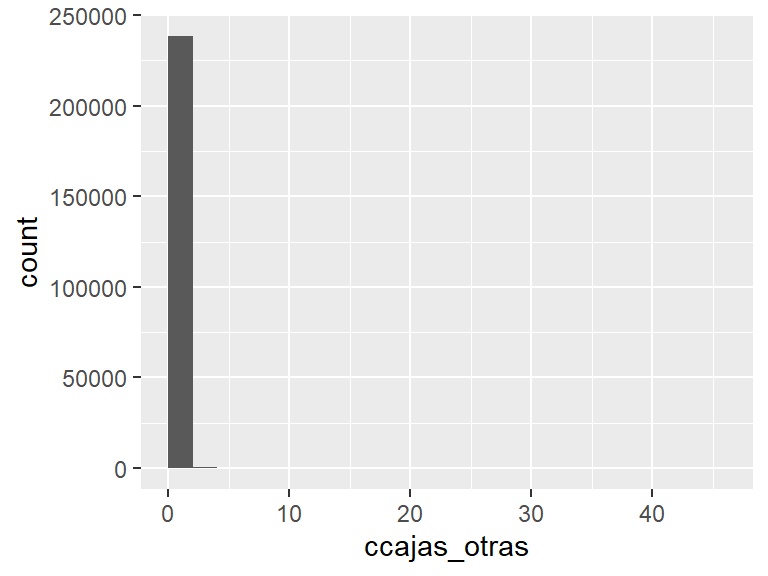

- Note that the following possible outlier values were detected: "1", "2", "3", "4", "5", "6", "7", "8", "9", "10" (9 additional values omitted).

## catm_trx

| Feature | Result |
| --- | --- |
| Variable type | integer |
| Number of missing obs. | 0 (0 %) |
| Number of unique values | 76 |
| Median | 0 |
| 1st and 3rd quartiles | 0; 2 |
| Min. and max. | 0; 100 |

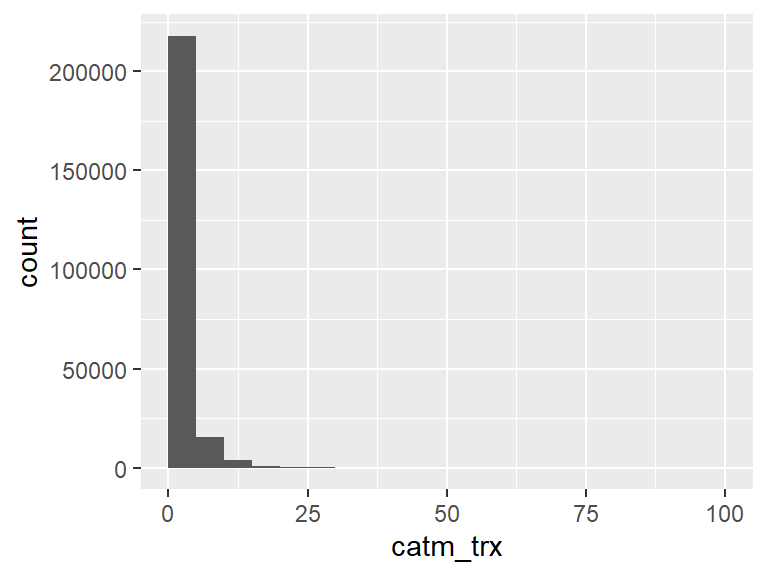

- Note that the following possible outlier values were detected: "63", "67", "68", "69", "70", "72", "73", "75", "76", "79" (5 additional values omitted).

## matm

| Feature | Result |
| --- | --- |
| Variable type | numeric |
| Number of missing obs. | 0 (0 %) |
| Number of unique values | 3087 |
| Median | 0 |
| 1st and 3rd quartiles | 0; 17550 |
| Min. and max. | 0; 2140135.62 |

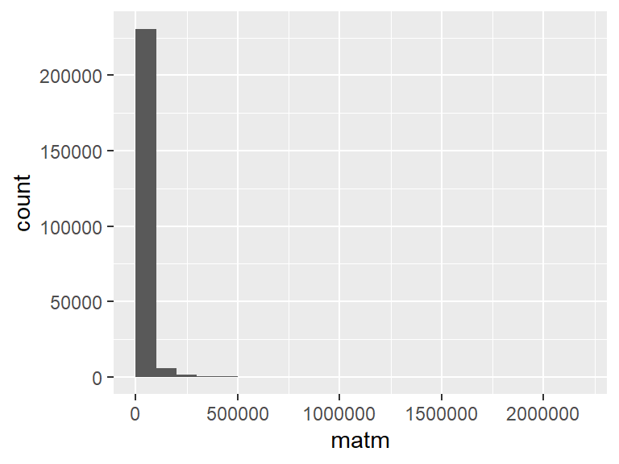

- Note that the following possible outlier values were detected: "549900", "552240", "554112", "554580", "555750", "556920", "558090", "559143", "561600", "566865" (104 additional values omitted).

## catm_trx_other

| Feature | Result |
| --- | --- |
| Variable type | integer |
| Number of missing obs. | 0 (0 %) |
| Number of unique values | 44 |
| Median | 0 |
| 1st and 3rd quartiles | 0; 0 |
| Min. and max. | 0; 78 |

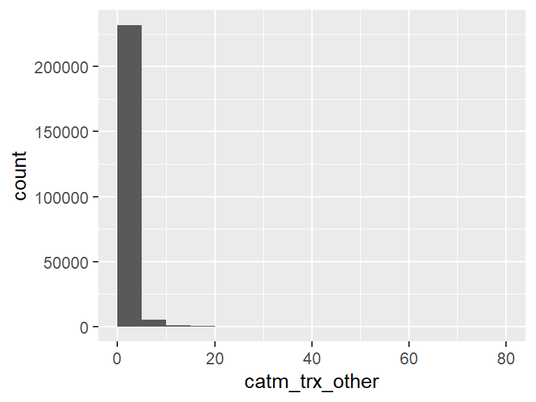

- Note that the following possible outlier values were detected: "1", "2", "3", "4", "5", "6", "7", "8", "9", "10" (33 additional values omitted).

## matm_other

| Feature | Result |
| --- | --- |
| Variable type | numeric |
| Number of missing obs. | 0 (0 %) |
| Number of unique values | 844 |
| Median | 0 |
| 1st and 3rd quartiles | 0; 0 |
| Min. and max. | 0; 3247574.96 |

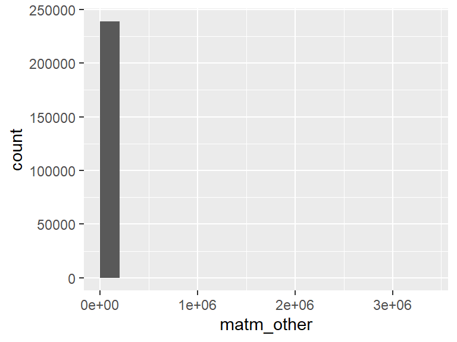

- Note that the following possible outlier values were detected: "117", "234", "351", "468", "585", "702", "819", "936", "1053", "1170" (833 additional values omitted).

## ctrx_quarter

| Feature | Result |
| --- | --- |
| Variable type | integer |
| Number of missing obs. | 0 (0 %) |
| Number of unique values | 917 |
| Median | 97 |
| 1st and 3rd quartiles | 55; 146 |
| Min. and max. | 0; 3033 |

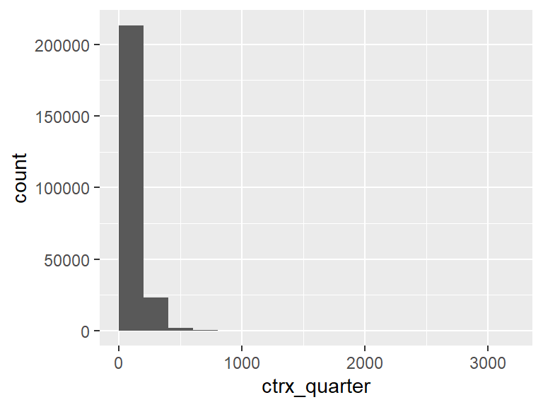

- Note that the following possible outlier values were detected: "346", "347", "348", "349", "350", "351", "352", "353", "354", "355" (561 additional values omitted).

## tmobile_app

- Note that this variable is treated as a factor variable below, as it only takes a few unique values.

| Feature | Result |
| --- | --- |
| Variable type | integer |
| Number of missing obs. | 0 (0 %) |
| Number of unique values | 2 |
| Mode | “0” |
| Reference category | 0 |

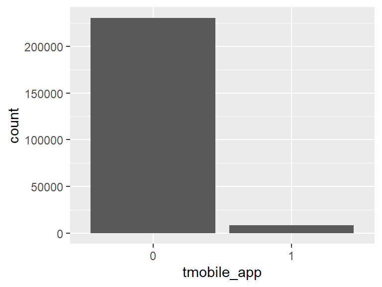

## cmobile_app_trx

- Note that this variable is treated as a factor variable below, as it only takes a few unique values.

| Feature | Result |
| --- | --- |
| Variable type | integer |
| Number of missing obs. | 0 (0 %) |
| Number of unique values | 2 |
| Mode | “1” |
| Reference category | 0 |

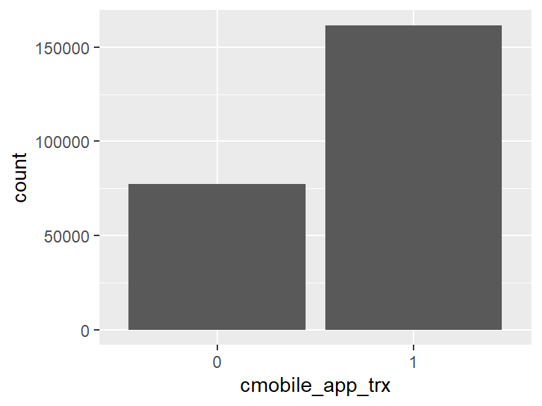

## Master_delinquency

- Note that this variable is treated as a factor variable below, as it only takes a few unique values.

| Feature | Result |
| --- | --- |
| Variable type | integer |
| Number of missing obs. | 23087 (9.66 %) |
| Number of unique values | 2 |
| Mode | “0” |
| Reference category | 0 |

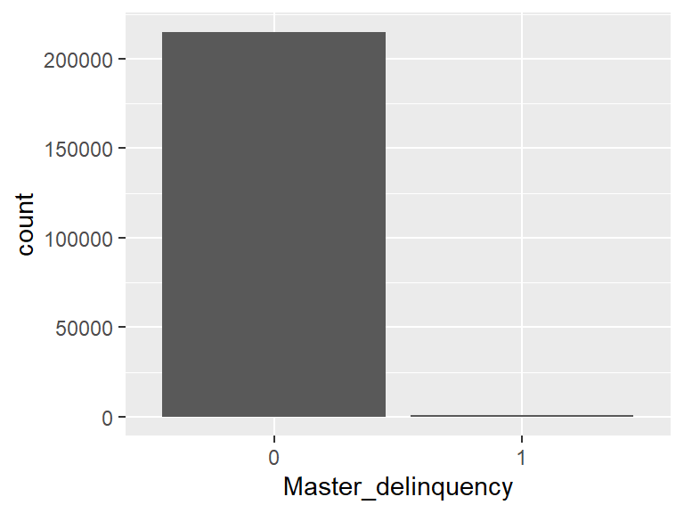

## Master_status

- Note that this variable is treated as a factor variable below, as it only takes a few unique values.

| Feature | Result |
| --- | --- |
| Variable type | integer |
| Number of missing obs. | 23087 (9.66 %) |
| Number of unique values | 4 |
| Mode | “0” |
| Reference category | 0 |

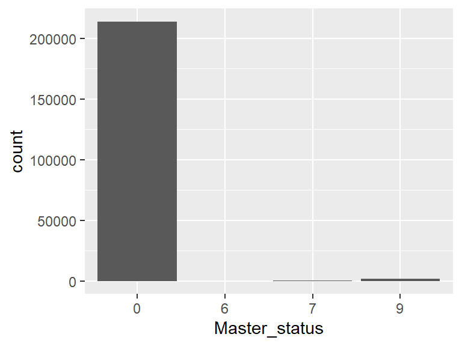

- The following suspected missing value codes enter as regular values: "9".
- Note that the following levels have at most five observations: "6".

## Master_mfinanciacion_limite

| Feature | Result |
| --- | --- |
| Variable type | numeric |
| Number of missing obs. | 23087 (9.66 %) |
| Number of unique values | 176 |
| Median | 176904 |
| 1st and 3rd quartiles | 88452; 453294.59 |
| Min. and max. | 0; 94280432.72 |

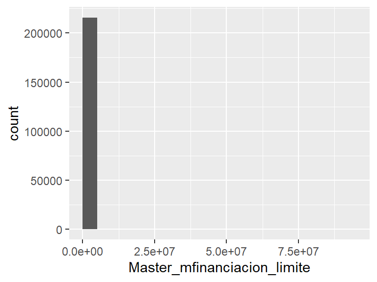

- Note that the following possible outlier values were detected: "0", "737.1", "884.52", "1031.94", "1105.65", "1179.36", "1326.78", "1474.2", "1547.91", "1769.04" (48 additional values omitted).

## Master_Fvencimiento

| Feature | Result |
| --- | --- |
| Variable type | integer |
| Number of missing obs. | 23087 (9.66 %) |
| Number of unique values | 169 |
| Median | -850 |
| 1st and 3rd quartiles | -1522; -607 |
| Min. and max. | -2914299; 6364 |

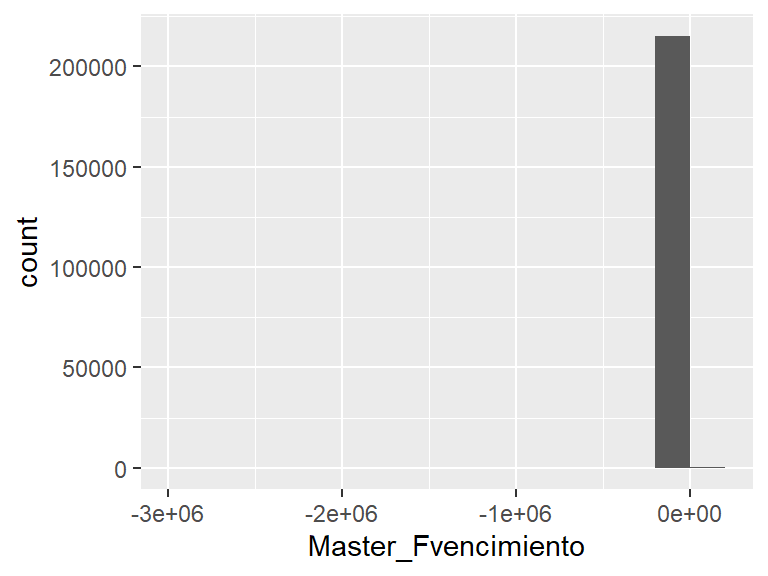

- Note that the following possible outlier values were detected: "-2914299", "-303", "-273", "-242", "-211", "-181", "-150", "-120", "-89", "-61" (95 additional values omitted).

## Master_Finiciomora

| Feature | Result |
| --- | --- |
| Variable type | integer |
| Number of missing obs. | 238073 (99.62 %) |
| Number of unique values | 14 |
| Median | 21 |
| 1st and 3rd quartiles | 21; 48 |
| Min. and max. | 4; 56 |

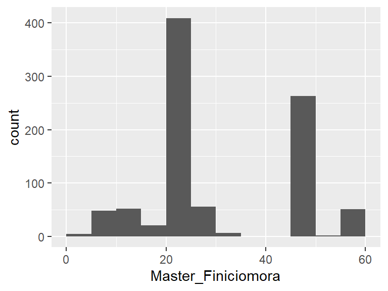

- Note that the following possible outlier values were detected: "4", "6", "12", "14", "19".

## Master_msaldototal

| Feature | Result |
| --- | --- |
| Variable type | numeric |
| Number of missing obs. | 23087 (9.66 %) |
| Number of unique values | 86300 |
| Median | 0 |
| 1st and 3rd quartiles | 0; 5075.04 |
| Min. and max. | -1141723.69; 3692523.97 |

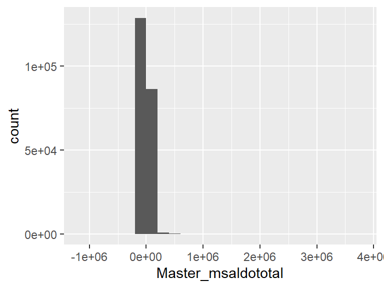

- Note that the following possible outlier values were detected: "-1141723.69", "-914408.03", "-899978.16", "-887211.93", "-802612.89", "-732276.71", "-703627.75", "-623070.99", "-607376.29", "-606959.92" (5850 additional values omitted).

## Master_msaldopesos

| Feature | Result |
| --- | --- |
| Variable type | numeric |
| Number of missing obs. | 23087 (9.66 %) |
| Number of unique values | 85893 |
| Median | 0 |
| 1st and 3rd quartiles | 0; 5038.04 |
| Min. and max. | -1141723.69; 3253223.82 |

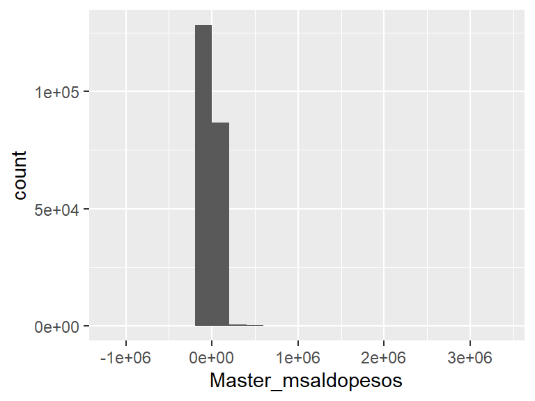

- Note that the following possible outlier values were detected: "-1141723.69", "-899978.16", "-887211.93", "-802612.89", "-732276.71", "-606959.92", "-495650.53", "-453730.05", "-435593.8", "-417358.89" (5109 additional values omitted).

## Master_msaldodolares

| Feature | Result |
| --- | --- |
| Variable type | numeric |
| Number of missing obs. | 23087 (9.66 %) |
| Number of unique values | 4709 |
| Median | 0 |
| 1st and 3rd quartiles | 0; 0 |
| Min. and max. | -733892.16; 1961534.21 |

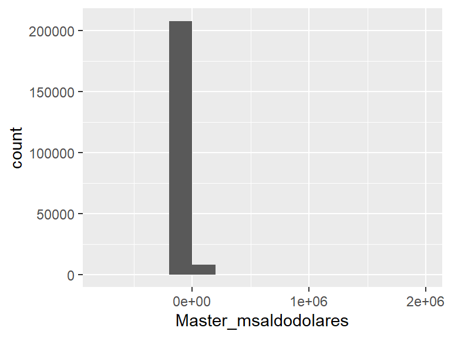

- Note that the following possible outlier values were detected: "-733892.16", "-623070.99", "-560048.4", "-508757.54", "-432683.12", "-396247.97", "-355993.24", "-351707.19", "-344733.77", "-339243.62" (4698 additional values omitted).

## Master_mconsumospesos

| Feature | Result |
| --- | --- |
| Variable type | numeric |
| Number of missing obs. | 145163 (60.74 %) |
| Number of unique values | 51556 |
| Median | 1986.66 |
| 1st and 3rd quartiles | 0; 9754.94 |
| Min. and max. | -57370.43; 2628725.29 |

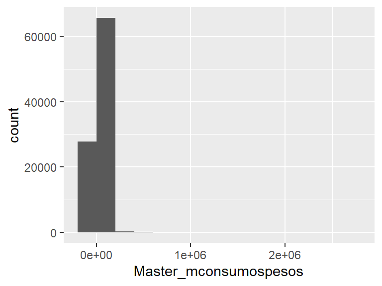

- Note that the following possible outlier values were detected: "-57370.43", "-33130.98", "-29657.86", "-20064.17", "-18296.95", "-16582.22", "-11629.91", "-11568.96", "-10791.49", "-9812.49" (1178 additional values omitted).